# VGG复现实验

## 实验目的

试编程实现VGG网络。我们这里选择VGG-16。

## 实验环境

PyTorch 2.4.0 CUDA 12.4

## 实验方法

### 选择深度学习框架

选择PyTorch作为本次实验的深度学习框架，主要是因为它提供了动态计算图的支持，这使得代码调试更加直观且易于理解。PyTorch拥有强大的社区支持和丰富的资源，这对于解决开发过程中遇到的问题非常有帮助。此外，PyTorch与CUDA的集成非常紧密，能够充分利用GPU加速计算，这对于拥有如3060 Laptop GPU这样支持CUDA操作的显卡的设备来说，意味着可以显著提升训练速度和效率。

### 数据集

ImageNet-1k 包含 1000 个类别的图像数据，每个类别代表现实世界中不同的物体或概念，如猫、狗、鸟等。在 ImageNet-1k 中，总共包含约 128 万张训练图像、5 万张验证图像和 10 万张测试图像。它是计算机视觉领域最常用的数据集之一，并被广泛用于深度神经网络模型（如 AlexNet、VGG、ResNet 等）的训练和评测。此外，ImageNet-1k 数据集常在 ILSVRC（ImageNet Large Scale Visual Recognition Challenge）中用于模型性能评测。

由于 ImageNet-1k 的总大小超过了100G，使用个人电脑很难在较短时间内完成下载和训练，我们使用 Tiny ImageNet 替代。Tiny ImageNet 是 ImageNet 数据集的简化版本，包含 200 个类别的 110,000 张图像 (100,000 张训练集与 10,000 张测试集)，每个类别有 500 张训练图像、50 张验证图像、以及 50 张测试图像。每张图像的尺寸为 64×64 像素。大部分图像为 RGB，少部分为灰度图，所以需要在预处理中统一格式。与 ImageNet-1k 相比，它更小、更易于管理，并且无需较大的计算资源，我们选择Tiny ImageNet 作为本次实验的数据集。相似地，Tiny ImageNet 可以通过`zh-plus/tiny-imagenet` 来加载。

预处理通常包括使用 `transforms` 进行数据增强以及标准化操作，将图像数据归一化到特定的均值和方差范围（例如：`mean=[0.485, 0.456, 0.406]` 和 `std=[0.229, 0.224, 0.225]`），并将其转换为 PyTorch 张量。在实验过程中，数据集应被划分为训练集、验证集和测试集三部分。Tiny ImageNet 提供了独立的验证集（10,000 张图像），然而没有提供测试集，测试集需要从验证集中单独划分，这可以通过 `torch.utils.data` 中的 `random_split` 函数来实现，比例可以选取为 8:2。

```python
from torchvision import transforms
from torch.utils.data import DataLoader, random_split
import torch
from datasets import load_dataset

# 确保所有图像是 RGB 格式
def ensure_rgb(image):
    if image.mode == 'L':
        return image.convert('RGB')
    return image

# 自定义 transform
transform = transforms.Compose([
    transforms.Resize((64, 64)),  # 调整图像尺寸为 64x64
    transforms.Lambda(ensure_rgb),  # 确保所有图像都是 RGB
    transforms.ToTensor(),  # 将图像转换为张量
    transforms.Normalize(mean=[0.485, 0.456, 0.406],  # 归一化
                         std=[0.229, 0.224, 0.225])
])

# 加载数据集
dataset = load_dataset('zh-plus/tiny-imagenet')

# 对训练集和验证集应用预处理
def transform_dataset(sample):
    return {
        'image': transform(sample['image']),  # 图像在 CPU 上转换为张量
        'label': torch.tensor(sample['label'], dtype=torch.long)  # 确保标签是长整型
    }

# 应用 transform
train_dataset = dataset['train'].map(transform_dataset, batched=False)
val_dataset = dataset['valid'].map(transform_dataset, batched=False)

# 转化为Torch Tensor
train_dataset.set_format(type='torch', columns=['image', 'label'])
val_dataset.set_format(type='torch', columns=['image', 'label'])

# 设置验证集与测试集的划分比例
val_size = int(0.8 * len(val_dataset))  # 80% 的数据作为验证集
test_size = len(val_dataset) - val_size  # 20% 的数据作为测试集

# 使用 random_split 划分验证集和测试集
val_dataset, test_dataset = random_split(val_dataset, [val_size, test_size])

# 输出数据集大小信息
print(f"训练集大小: {len(train_dataset)}")
print(f"验证集大小: {len(val_dataset)}")
print(f"测试集大小: {len(test_dataset)}")
```

```
训练集大小: 100000
验证集大小: 8000
测试集大小: 2000
```

展示一些数据集中的样本

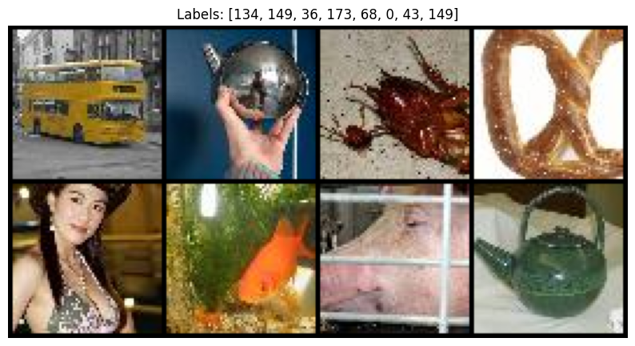

```python
import matplotlib.pyplot as plt
import torch
import torchvision
from torch.utils.data import DataLoader
from torchvision import transforms

unnormalize = transforms.Normalize(
    mean=[-0.485 / 0.229, -0.456 / 0.224, -0.406 / 0.225],
    std=[1/0.229, 1/0.224, 1/0.225]
)

def show_image_grid(image_tensor, labels, num_images):
    # 取消归一化
    image_tensor = torch.stack([unnormalize(img) for img in image_tensor])

    # 使用 make_grid 生成图像网格
    grid_img = torchvision.utils.make_grid(image_tensor, nrow=num_images//2)

    # 转换为 NumPy 格式并显示
    plt.figure(figsize=(10, 10))
    plt.imshow(grid_img.permute(1, 2, 0).numpy())
    plt.title(f'Labels: {labels.tolist()}')
    plt.axis('off')
    plt.show()

train_loader = DataLoader(train_dataset, batch_size=8, shuffle=True)
data_iter = iter(train_loader)
batch = next(data_iter)
images, labels = batch['image'], batch['label']

# 可视化前 8 张图像
show_image_grid(images, labels, num_images=8)
```

### VGG

VGG网络是由牛津大学计算机视觉组和谷歌DeepMind团队共同提出的，在2014年的ImageNet挑战赛上表现非常出色。其最大的特点是使用了**非常深的网络结构**，而且网络中的卷积层只使用了3x3的小卷积核，保持了简单而一致的设计原则。VGG 网络有多个变种，其中最常用的是 **VGG-16** 和 **VGG-19**，数字表示网络中包含的层数。**VGG-16** 是 VGG 网络中最经典的结构之一，包含 13 个卷积层和 3 个全连接层，总共 16 层。这种深层结构可以提取出非常细致的特征，从而在分类任务中表现出色。 VGG-16 的网络结构可以分为多个卷积块（Convolutional Block），每个卷积块中包含多个卷积层，之后紧跟一个最大池化层来缩小特征图尺寸。以下是 VGG-16 的具体结构：

#### 卷积块 1

- **卷积层 1-1**: 64 个 3x3 卷积核，padding=1。
- **卷积层 1-2**: 64 个 3x3 卷积核，padding=1。
- **最大池化层 1**: 2x2, stride=2。

#### 卷积块 2

- **卷积层 2-1**: 128 个 3x3 卷积核，padding=1。
- **卷积层 2-2**: 128 个 3x3 卷积核，padding=1。
- **最大池化层 2**: 2x2, stride=2。

#### 卷积块 3

- **卷积层 3-1**: 256 个 3x3 卷积核，padding=1。
- **卷积层 3-2**: 256 个 3x3 卷积核，padding=1。
- **卷积层 3-3**: 256 个 3x3 卷积核，padding=1。
- **最大池化层 3**: 2x2, stride=2。

#### 卷积块 4

- **卷积层 4-1**: 512 个 3x3 卷积核，padding=1。
- **卷积层 4-2**: 512 个 3x3 卷积核，padding=1。
- **卷积层 4-3**: 512 个 3x3 卷积核，padding=1。
- **最大池化层 4**: 2x2, stride=2。

#### 卷积块 5

- **卷积层 5-1**: 512 个 3x3 卷积核，padding=1。
- **卷积层 5-2**: 512 个 3x3 卷积核，padding=1。
- **卷积层 5-3**: 512 个 3x3 卷积核，padding=1。
- **最大池化层 5**: 2x2, stride=2。

#### 全连接层

- **全连接层 1**: 输入为展平后的特征图（这里使用`self._init_fc_size()`自动计算），输出 4096 个神经元。
- **全连接层 2**: 4096 个神经元。
- **全连接层 3**: 1000 个神经元（ImageNet-1k 分类任务中有 1000 类）。

除最后一层使用SoftMax外，其余各层均使用ReLU激活函数。

#### Dropout

Dropout 是一种防止神经网络过拟合的正则化技术。在训练时，它以一定概率（如 50%）随机“丢弃”部分神经元，使网络在每次前向传播中只使用部分神经元，降低神经元之间的共适应性，增强模型的泛化能力。在 VGG-16 中，Dropout 被应用于全连接层部分，概率为 0.5，表示在训练时有 50% 的神经元被随机丢弃。由于全连接层参数较多，容易发生过拟合，Dropout 帮助减少这一问题。训练时随机丢弃神经元，测试时所有神经元保留。

#### 批次归一化

批次归一化（Batch Normalization）通过将每一层的输入标准化为均值为0、方差为1的分布，加速模型训练并稳定收敛。它在每个批次上计算输入特征的均值和方差，对输入进行标准化后再进行缩放和平移，从而保持数据分布的灵活性。批次归一化通常添加在激活函数之前，尤其适用于深层网络如VGG-16，以缓解梯度消失或梯度爆炸问题并提高泛化能力。

由于我们的数据集图片为64*64且只有200类，我们需要更改分类器部分的设计，

```python
import torch
import torch.nn as nn
import torch.nn.functional as F

CHANNELS1 = 64
CHANNELS2 = 128
CHANNELS3 = 256
CHANNELS4 = 512

class VGG16(nn.Module):
    def __init__(self, input_size:int=CHANNELS1, num_classes:int=200):
        super(VGG16, self).__init__()

        # VGG-16 的卷积层部分，加入Batch Normalization
        self.features = nn.Sequential(
            # 卷积块 1
            nn.Conv2d(3, CHANNELS1, kernel_size=3, padding=1),
            nn.BatchNorm2d(CHANNELS1),  # 加入Batch Normalization
            nn.ReLU(inplace=True),
            nn.Conv2d(CHANNELS1, CHANNELS1, kernel_size=3, padding=1),
            nn.BatchNorm2d(CHANNELS1),  # 加入Batch Normalization
            nn.ReLU(inplace=True),
            nn.MaxPool2d(kernel_size=2, stride=2),  # 输出尺寸减半

            # 卷积块 2
            nn.Conv2d(CHANNELS1, CHANNELS2, kernel_size=3, padding=1),
            nn.BatchNorm2d(CHANNELS2),  # 加入Batch Normalization
            nn.ReLU(inplace=True),
            nn.Conv2d(CHANNELS2, CHANNELS2, kernel_size=3, padding=1),
            nn.BatchNorm2d(CHANNELS2),  # 加入Batch Normalization
            nn.ReLU(inplace=True),
            nn.MaxPool2d(kernel_size=2, stride=2),  # 输出尺寸减半

            # 卷积块 3
            nn.Conv2d(CHANNELS2, CHANNELS3, kernel_size=3, padding=1),
            nn.BatchNorm2d(CHANNELS3),  # 加入Batch Normalization
            nn.ReLU(inplace=True),
            nn.Conv2d(CHANNELS3, CHANNELS3, kernel_size=3, padding=1),
            nn.BatchNorm2d(CHANNELS3),  # 加入Batch Normalization
            nn.ReLU(inplace=True),
            nn.Conv2d(CHANNELS3, CHANNELS3, kernel_size=3, padding=1),
            nn.BatchNorm2d(CHANNELS3),  # 加入Batch Normalization
            nn.ReLU(inplace=True),
            nn.MaxPool2d(kernel_size=2, stride=2),  # 输出尺寸减半

            # 卷积块 4
            nn.Conv2d(CHANNELS3, CHANNELS4, kernel_size=3, padding=1),
            nn.BatchNorm2d(CHANNELS4),  # 加入Batch Normalization
            nn.ReLU(inplace=True),
            nn.Conv2d(CHANNELS4, CHANNELS4, kernel_size=3, padding=1),
            nn.BatchNorm2d(CHANNELS4),  # 加入Batch Normalization
            nn.ReLU(inplace=True),
            nn.Conv2d(CHANNELS4, CHANNELS4, kernel_size=3, padding=1),
            nn.BatchNorm2d(CHANNELS4),  # 加入Batch Normalization
            nn.ReLU(inplace=True),
            nn.MaxPool2d(kernel_size=2, stride=2),  # 输出尺寸减半

            # 卷积块 5
            nn.Conv2d(CHANNELS4, CHANNELS4, kernel_size=3, padding=1),
            nn.BatchNorm2d(CHANNELS4),  # 加入Batch Normalization
            nn.ReLU(inplace=True),
            nn.Conv2d(CHANNELS4, CHANNELS4, kernel_size=3, padding=1),
            nn.BatchNorm2d(CHANNELS4),  # 加入Batch Normalization
            nn.ReLU(inplace=True),
            nn.Conv2d(CHANNELS4, CHANNELS4, kernel_size=3, padding=1),
            nn.BatchNorm2d(CHANNELS4),  # 加入Batch Normalization
            nn.ReLU(inplace=True),
            nn.MaxPool2d(kernel_size=2, stride=2)  # 输出尺寸减半
        )

        # 动态计算特征图大小
        self._init_fc_size(input_size)

        # VGG-16 的全连接层部分
        self.classifier = nn.Sequential(
            nn.Linear(self.flattened_size, 1024),
            nn.ReLU(inplace=True),
            nn.Dropout(),
            nn.Linear(1024, 1024),
            nn.ReLU(inplace=True),
            nn.Dropout(),
            nn.Linear(1024, num_classes)  # 输出为分类数
        )

        self.softmax = nn.Softmax(dim=1)

        torch.nn.init.kaiming_normal_(self.classifier[0].weight, nonlinearity='relu')

    def _init_fc_size(self, input_size):
        # 用一个假数据通过卷积层来计算最后的特征图大小
        dummy_input = torch.zeros(1, 3, input_size, input_size)
        dummy_output = self.features(dummy_input)
        self.flattened_size = dummy_output.numel()

    def forward(self, x) -> torch.Tensor:
        x = self.features(x)
        x = torch.flatten(x, 1)
        x = self.classifier(x)
        return x

    def predict(self, x):
        logits = self.forward(x)
        probs = self.softmax(logits)
        return probs
```

## 实验流程

### 训练

由于这是典型的分类问题，我们使用交叉熵损失： $$ L = - \sum_{i} y_i \log(\hat{y}_i) $$ 其中：

- $ y_i $ 是样本的真实标签。
- $ \hat{y}_i $ 是模型预测的类别概率。

在 PyTorch 中，交叉熵损失通过 `nn.CrossEntropyLoss()` 实现，该函数将 softmax 和负对数似然损失结合在一起，因此不需要手动添加 softmax 层。

```python
import torch.nn as nn
from utils.train import train_model

model = VGG16(num_classes=200, input_size=64)
device = torch.device('cuda' if torch.cuda.is_available() else 'cpu')

train_model(model, train_dataset, val_dataset,
            criterion_class=nn.CrossEntropyLoss,
            epochs=256,
            learning_rate=1e-3,
            batch_size=64,
            clip_grad_value=1.0,
            use_scheduler=True,
            )
```

显示loss和accu曲线

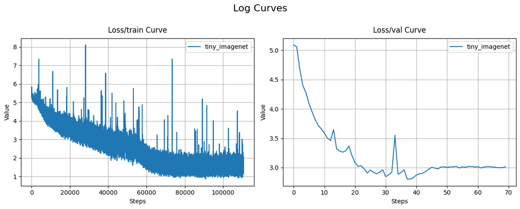

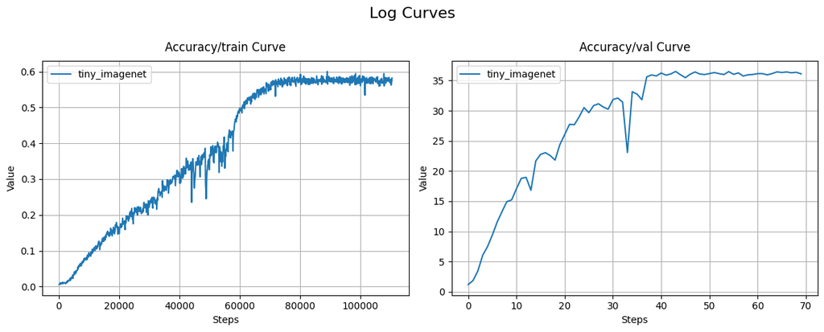

```python
from utils.plot import plot_curves

plot_curves('logs/tiny', ['Loss/train', 'Loss/val'])
plot_curves('logs/tiny', ['Accuracy/train', 'Accuracy/val'])
```

可以看到，训练一段时间后，Loss不再下降，Accu不再上升，说明可以终止训练了。整体Loss很不稳定，波动较大，下降不是很快，并且可能出现了梯度消失问题。最终训练准确率58%左右，而验证准确率36%左右，说明模型有一定的过拟合现象。训练的时候loss下降很慢，导致训练周期很长，这可能就是之后ResNet诞生的原因。

### 测试

测试模型

```python
from utils.test import test_model

model = VGG16(num_classes=200, input_size=64)
model.load_state_dict(torch.load('checkpoints/tiny_best.pth', weights_only=True))
test_model(model, test_dataset, criterion_class=nn.CrossEntropyLoss, batch_size=64)
```

```
Test Loss: 2.8050, Test Accuracy: 37.05%
```

```
(2.804982460021973, 37.05)
```

测试准确率为37.05%，与验证集一致，但是没有达到预期。这可能是因为：

1. Tiny-ImageNet数据集图像为64*64，辨识度不如ImageNet-1k数据集的224*224图像；
2. 模型训练过程中可能出现了梯度消失问题，训练不充分；
3. 模型出现了过拟合现象，`classifier`部分可能过于复杂。 但是准确率仍然比随机选择的0.5%高出74倍，说明模型学到了有效的信息。由于算力限制，我们不再进行后续探究实验。